# Proyecto 2

Andrés Villaseñor

1 de junio de 2015

#### Introducción

El objetivo del *proyecto 2* es responder a las preguntas planteadas en la lectura 3 del repositorio de big data encontrado [aqui](https://github.com/andreslechuga/big-data/blob/master/lecture_3/lecture_3.md), por lo que se realiza la carga de las bases de datos que se presentarán a continuación y su posterior analísis.

#### Base de datos

Para el segundo proyecto se utilizan 2 bases de datos. * La primera es de avistamientos de [UFOS](http://www.nuforc.org) la cual contiene una descripción de los avisamientos ocurridos y documentados desde antes de 1900´s hasta la fecha. * La segunda es la base de datos de noticias[GDELT](http://gdeltproject.org) el cual es un proyecto que contiene más de 300 millones de eventos geolocalizados desde 1979 a la fecha.

#### Análisis UFO

**1.1 ¿Primer avistamiento en cada estado?**

```
##    state       date
## 1     LA 1969-01-01
## 2     NV 1969-01-01
## 3     PA 1969-01-01
## 4     FL 1969-01-04
## 5     MT 1969-01-15
## 6     IN 1969-02-15
## 7     IL 1969-03-01
## 8     NE 1969-03-01
## 9     NJ 1969-03-01
## 10    OK 1969-03-15
```

**1.2 ¿Primer avistamiento de cada forma?**

```
##        shape       date
## 1      Other 1969-01-01
## 2   Triangle 1969-01-01
## 3    Unknown 1969-01-01
## 4       Oval 1969-01-04
## 5      Light 1969-01-15
## 6  Rectangle 1969-01-15
## 7     Sphere 1969-01-15
## 8       Disk 1969-01-20
## 9      Cigar 1969-02-12
## 10     Cross 1969-03-15
```

**2. ¿Promedio de avistamientos, por mes, por año? ¿Por estado?**

promedio por año

```
## Source: local data frame [10 x 3]
##
##    year(date) count         prom_anio
## 1        1969   183 3.893617021276596
## 2        1970   174 3.702127659574468
## 3        1971   142 3.021276595744681
## 4        1972   202 4.297872340425532
## 5        1973   264 5.617021276595745
## 6        1974   309 6.574468085106383
## 7        1975   366 7.787234042553192
## 8        1976   327 6.957446808510638
## 9        1977   304 6.468085106382978
## 10       1978   386 8.212765957446809
```

promedio por mes

```
## Source: local data frame [10 x 3]
##
##    month(date) count         prom_anio
## 1            1  6871 572.5833333333334
## 2            2  5519 459.9166666666667
## 3            3  6482 540.1666666666666
## 4            4  6380 531.6666666666666
## 5            5  6342 528.5000000000000
## 6            6  9413 784.4166666666666
## 7            7 11231 935.9166666666666
## 8            8 10168 847.3333333333334
## 9            9  9086 757.1666666666666
## 10          10  8875 739.5833333333334
```

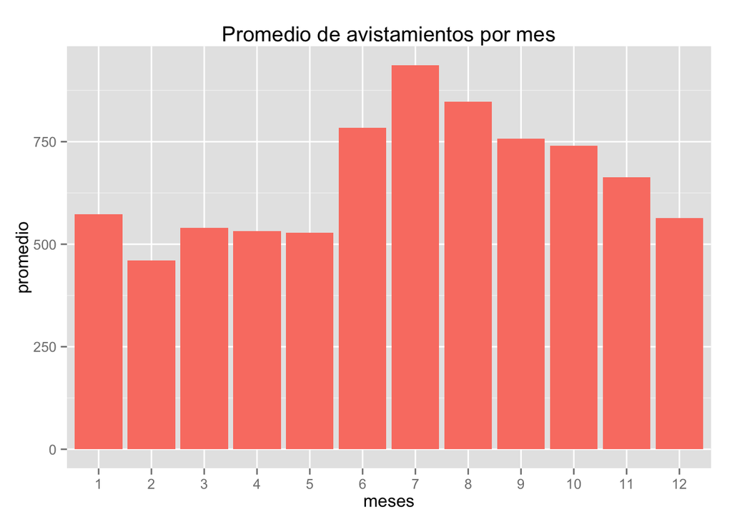

promedio por estado

```
## Source: local data frame [10 x 3]
##
##    state count        prom_estado
## 1     CA 11209 160.12857142857143
## 2     FL  5134  73.34285714285714
## 3     WA  5015  71.64285714285714
## 4     TX  4367  62.38571428571429
## 5     NY  3842  54.88571428571429
## 6     AZ  3234  46.20000000000000
## 7     PA  3149  44.98571428571429
## 8     IL  3060  43.71428571428572
## 9     OH  2912  41.60000000000000
## 10    MI  2454  35.05714285714286
```

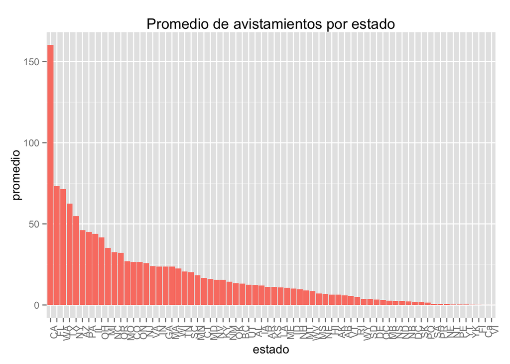

**3. ¿Cuál estado tiene mayor varianza?**

```
## Source: local data frame [10 x 5]
##
##    state count           prom_estado              std_d
## 1     CA 11209 160.12857142857143344 98661934.816530615
## 2     FL  5134  73.34285714285714164 14883171.959387755
## 3     WA  5015  71.64285714285713880 13979159.559387755
## 4     TX  4367  62.38571428571428612  9553486.187959185
## 5     NY  3842  54.88571428571428612  6583696.187959184
## 6     AZ  3234  46.20000000000000284  3833260.530816327
## 7     PA  3149  44.98571428571428754  3507647.387959184
## 8     IL  3060  43.71428571428571530  3182197.273673470
## 9     OH  2912  41.60000000000000142  2676075.330816327
## 10    Ca     1   0.01428571428571429  1625952.873673469
## Variables not shown: varianza (dbl)
```

**4. ¿Existen olas temporales?**

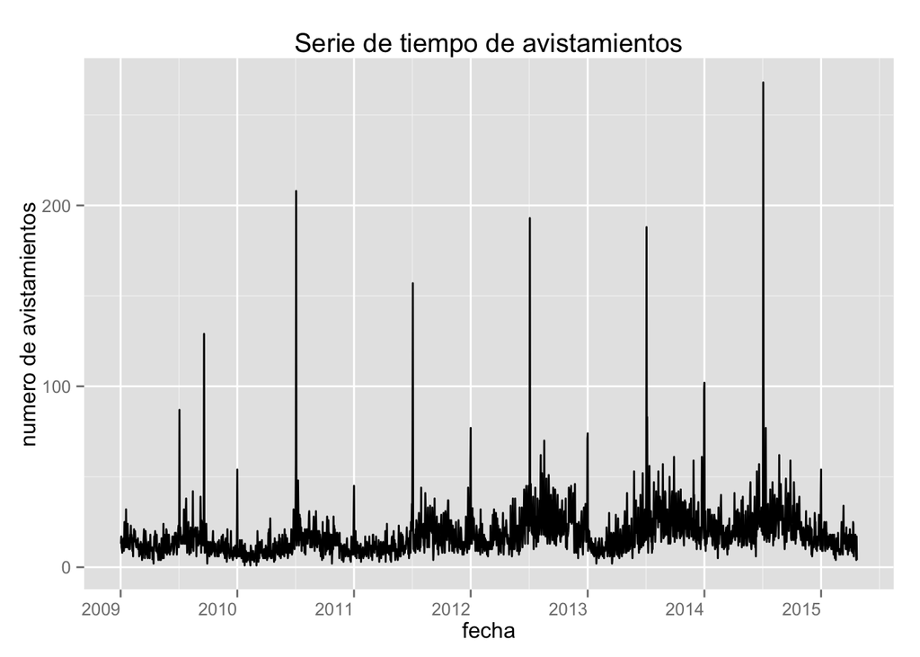

Al parecer se repite un patron en el que los picos son más notables es decir al parecer en verano la gente ve mas ovnis, ya que parece que la serie es estacionaria.

**5. ¿Narrativas parecidas?**

Realizamos minería de texto para crear un corpus, limpiarlo y a traves de una clusterización podemos fijarnos si hay narrativas similares. Considero que esto es mejor que buscar similitud de texto ya que sería más dificíl encontrar similitudes por que es una técnica un poco más estricta.

```
## cl
##     1     2     3     4     5     6     7     8     9    10    11    12
##  2155 25946  1030  6476  4694  2553  3044  2102  4741  2641  5234  3196
##    13    14    15    16    17    18    19    20
##  2341  8894  3312  5088  2915  3827  2700  4259
```

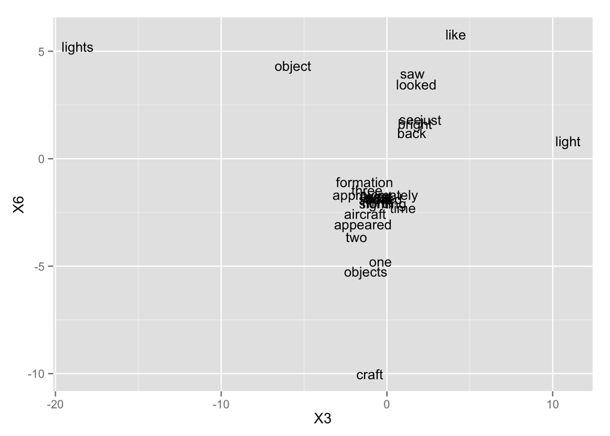

**6. ¿Cómo está relacionado con la geografía?**

Al parecer no hay relación geográfica mayor, sin embargo es notable como en califormia hay varios avistamientos, también en la región noreste hay bastantes avistamientos.

**7. ¿Con características sociales?**

[figure not shown]

Utilizamos un censo de población, la imágen de la izquierda en la gráfica muestra el número de avistamientos y la imagen de la derecha mustra el tamaño de población estimado por estado. Aparentemente existe una relación entre estas dos variables ya que las gráficas son casi idénticas.

**8. Desarrolla un modelo predictivo**

```
##  [1] 1041.227304217737 1100.538032044436 1111.392292019260
##  [4] 1192.150048060397 1023.140143980806 1052.434917330405
##  [7] 1034.328331048304 1078.139235986450 1084.231091185184
## [10] 1124.472623051115 1091.619528545428
```

```
##  [1]   773 11209  5134  1665   767   746  1285   502   630  3842  1674
## [12]   598
```

Utilizamos el paquete de *caret* y *“svmRadial”* para hacer el modelo. No hay muchos datos con los cuales entrenar por lo que nuestra estimación no es muy buena.

#### Análisis GDELT

A continuación exploraremos los eventos ocurridos en México. Primero vemos el número de reportes de México en el tiempo y su evolución, es natural observar que a partir del 2008 se generaron muchos más eventos. Esto podría deberse a la crisis y la implementación del gobierno y la lucha contra el narcotráfico.

```
##    month.year reports
## 1      197901     233
## 2      197902     343
## 3      197903     149
## 4      197904     198
## 5      197905     291
## 6      197906     309
## 7      197907     357
## 8      197908     175
## 9      197909     186
## 10     197910     212
```

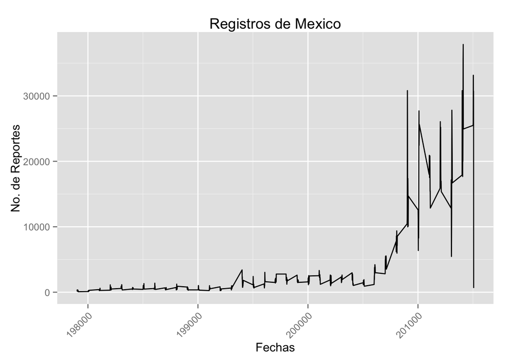

Si suavisamos un poco la serie de tiempo tenemos que se notan tres grandes picos en los eventos, estos corresponden:

- La erupción del volcán Chichonal
- El levantamiento del ejército zapatista
- El brote de H1N1

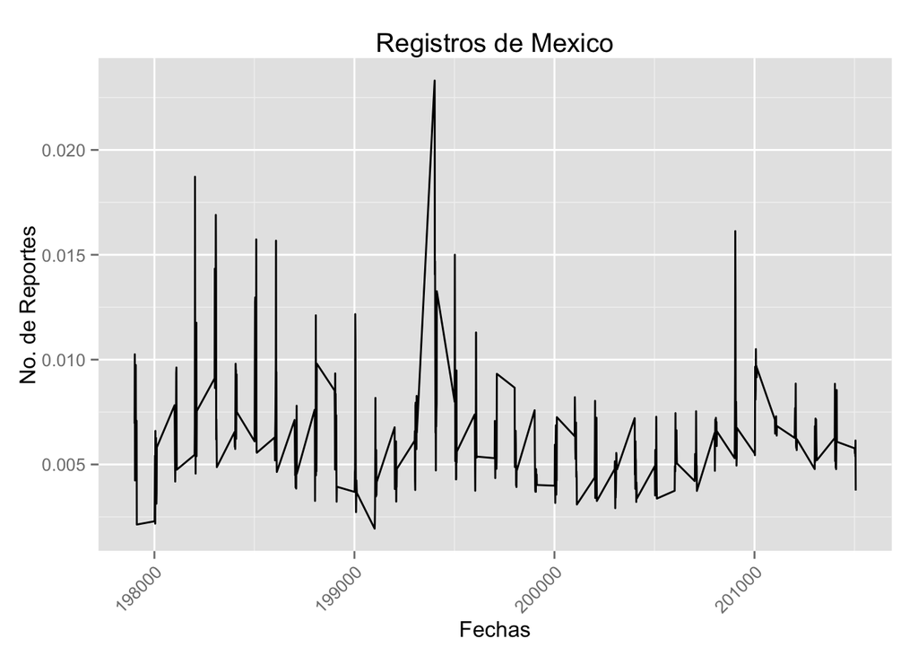

Vemos los datos que corresponden a conflictos

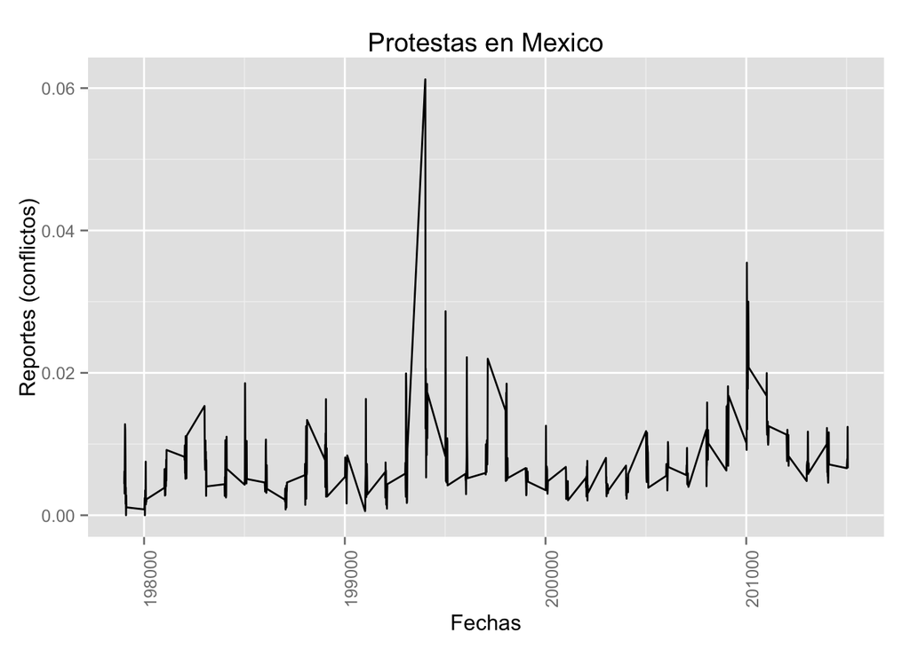

Si observamos los datos en México, podemos ver que casi todo el país está lleno de sucesos :( sin embargo hay que notar que hay focos en dónde existen puntos de calor, a continuación mostramos el top 10 de las ciudades más mencionadas.

[figure not shown]

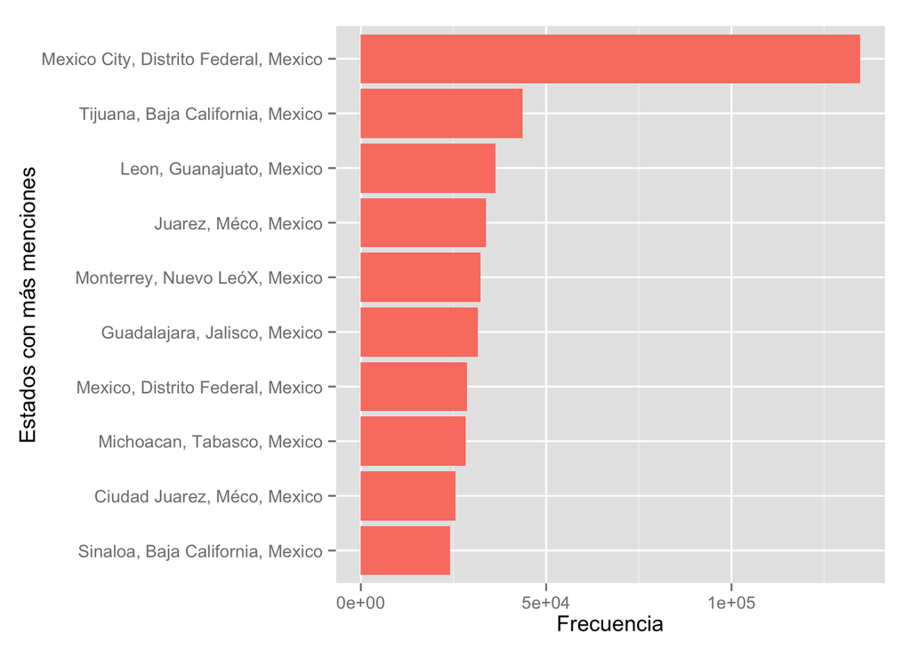

Promedio de eventos por estado.

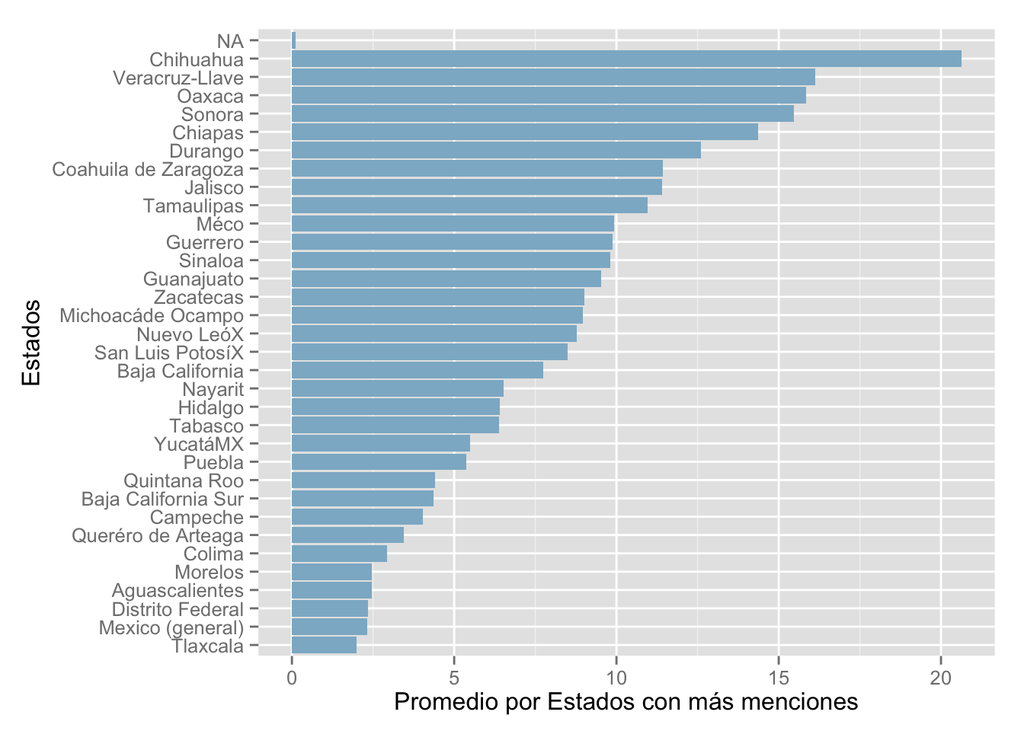